# Zero-inflated Poisson Generalized Additive Model fitted using the EM Algorithm

S. Wotherspoon and P. Burch

21 March 2016

# Introduction

The **mgcv** package (Wood (2006)) implements zero-inflated Poisson Generalised Additive Models (GAMs) with smoothing parameter estimation by either restricted maximum likelihood (REML) or maximum likelihood (ML). However, it does not permit for the inclusion of an offset term in the model.

The **zigam** package implements zero-inflated GAMs using the EM Algorithm (Pawitan (2001)) which permits the inclusion of an offset. The predictions should be reliable, but standard errors (and possibly the level of smoothing chosen) will be unreaslistic. Confidence intervals are therefore estimated using a parametric bootstrap (Efron and Tibshirani (1993)).

# Example - Simulated Data

Set a seed for repeatability

```r
set.seed(12032016)
```

Simulate some data to test

```r
n <- 5000
x1 <- runif(n)
x2 <- runif(n)
ilogit <- function(x) 1/(1+exp(-x))
p <- ilogit(sin(2*pi*x1)*sin(2*pi*x2))
lambda <- exp(10*x1*(1-x1))
z <- rbinom(n,1,p)
y <- rpois(n,lambda*z)
d <- data.frame(x1=x1,x2=x2,y=y)
```

Load the **mgcv** and **zigam** packages.

```r
library(mgcv)
library(zigam)
```

Fit a zero-inflated Poisson model.

```r
fit <- zipgam(y ~ s(x1,x2),
              ~ s(x1,x2),
              data=d)
```

```
##  [1] -8595.437 -8575.942 -8573.311 -8572.421 -8572.055 -8571.888 -8571.806
##  [8] -8571.765 -8571.743 -8571.732 -8571.726
```

Show the inflation model (actually the model for this being a Poisson count)

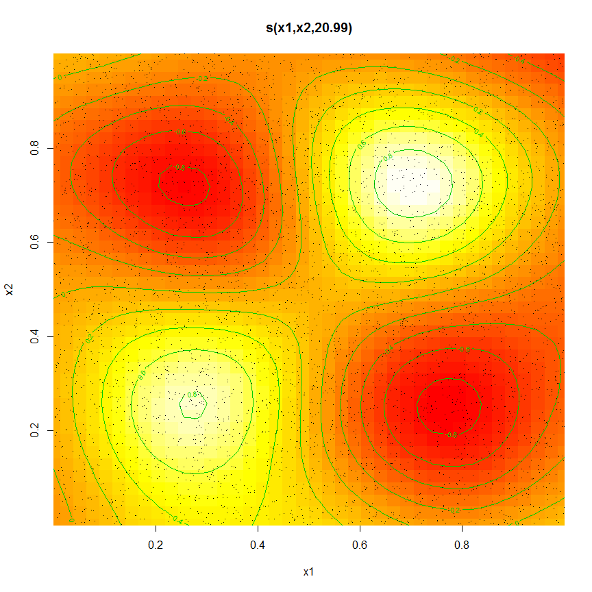

```r
plot(fit$fit.pi,select=1,scheme=2)
```

and the model for the mean of the Poisson counts (with the additional zeroes removed)

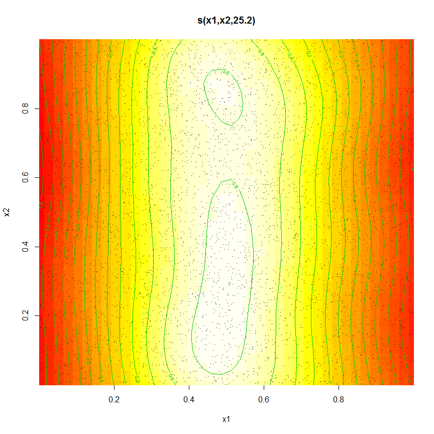

```r
plot(fit$fit.lambda,select=1,scheme=2)
```

## Parametric Bootstrap

A difficulty with the EM algorithm is that the estimated standard errors from the two stages of the fit tend to be underestimated, because each fails to recognize the variability in the other.

One approach to estimating variability is the parametric bootstrap - we fit the model to the data, simulate new data from the model and then refit the model to the new data.

Simulate a small data set (for speed)

```r
n <- 200
x1 <- runif(n)
x2 <- runif(n)
ilogit <- function(x) 1/(1+exp(-x))
p <- ilogit(1+sin(2*pi*x2))
lambda <- exp(10*x1*(1-x1))
z <- rbinom(n,1,p)
y <- rpois(n,lambda*z)
d <- data.frame(x1=x1,x2=x2,y=y)
```

Fit a simple model

```r
fit <- zipgam(y ~ s(x1),
              ~ s(x2),
              data=d)
```

```
## [1] -396.4938 -395.5590 -395.4072 -395.3700 -395.3602 -395.3575
```

If the data we wish to predict for is

```r
x1.pred <- seq(0,1,length.out=40)
d.pred <- data.frame(x1=x1.pred,x2=rep(0,40))
```

Then the parametric bootstrap for the predicted responses is

```r
d.boot <- d
boot <- sapply(simulate(fit,20),function(s) {
  ## Update response
  d.boot[,"y"] <- s;
  ## Refit model and generate predictions
  fit.boot <- update(fit,data=d.boot)
  predict(fit.boot,d.pred,type="response")
})
```

```
## [1] -407.9682 -407.2495 -407.1690 -407.1539 -407.1508 -407.1502
## [1] -414.9234 -414.0319 -413.8988 -413.8670 -413.8586 -413.8562
## [1] -399.9395 -398.3984 -398.0681 -397.9630 -397.9251 -397.9110 -397.9058
## [1] -414.7633 -413.7082 -413.5128 -413.4628 -413.4489 -413.4449
## [1] -391.0696 -390.4300 -390.3612 -390.3487 -390.3461 -390.3455
## [1] -408.8053 -407.9801 -407.8568 -407.8201 -407.8072 -407.8026
## [1] -424.3627 -423.9571 -423.9175 -423.9101 -423.9086 -423.9082
## [1] -389.5677 -389.0599 -389.0280 -389.0234 -389.0226 -389.0225
## [1] -406.9513 -406.3762 -406.3017 -406.2860 -406.2825 -406.2818
## [1] -407.1014 -406.1118 -405.9928 -405.9710 -405.9661 -405.9650
## [1] -392.3214 -391.3873 -391.3310 -391.3209 -391.3179 -391.3169
## [1] -392.1117 -390.9886 -390.8321 -390.7927 -390.7816 -390.7784
## [1] -411.4836 -410.9145 -410.9004 -410.9048 -410.9068 -410.9075
## [1] -391.0101 -389.9924 -389.8618 -389.8350 -389.8292 -389.8279
## [1] -403.2388 -401.5772 -401.2651 -401.1835 -401.1596 -401.1523
## [1] -415.5669 -413.8616 -413.5308 -413.4361 -413.4066 -413.3973
## [1] -425.2523 -423.6319 -423.2926 -423.1941 -423.1626 -423.1522 -423.1487
## [1] -425.8181 -426.2056 -426.3293 -426.3576 -426.3645 -426.3663
## [1] -406.0898 -404.6251 -404.2704 -404.1606 -404.1247 -404.1127 -404.1088
## [1] -405.3815 -404.8307 -404.7854 -404.7768 -404.7752 -404.7749
```

Extract the quantiles and plot

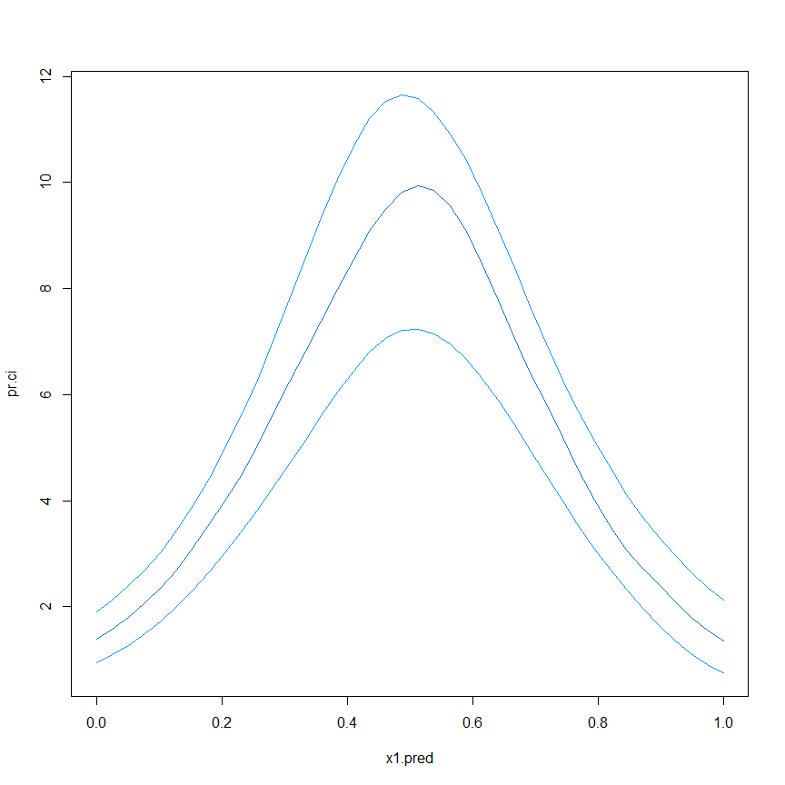

```r
pr.ci <- t(apply(boot,1,quantile,prob=c(0.025,0.5,0.975)))
matplot(x1.pred,pr.ci,type="l",lty=1,
        col=c("dodgerblue1","dodgerblue3","dodgerblue1"))
```

References

Efron, B, and R. J. Tibshirani. 1993. *An Introduction to the Bootstrap*. Monographs on Statistics and Applied Probability. Chapman; Hall.

Pawitan, Yudi. 2001. *In All Likelihood: Statistical Modelling and Inference Using Likelihood*. 1st ed. Oxford University Press, USA.

Wood, Simon N. 2006. *Generalized Additive Models an Introduction with R*. Chapman; Hall/CRC.